# Tarea Hidrologia

## Tarea exploración de datos hidrológios R Markdown

### Curso: Procesamiento de Datos Geográficos

### Estudiante: Ignacio Quirós Paniagua

### Carné: C06253

La idea de la tarea es la observación, análisis y creación de gráficos estadísticos utilizando los datos de los caudales recolectados durante el periodo de 1973-1983 del Rio Estrella y Rio Banano en Costa Rica.

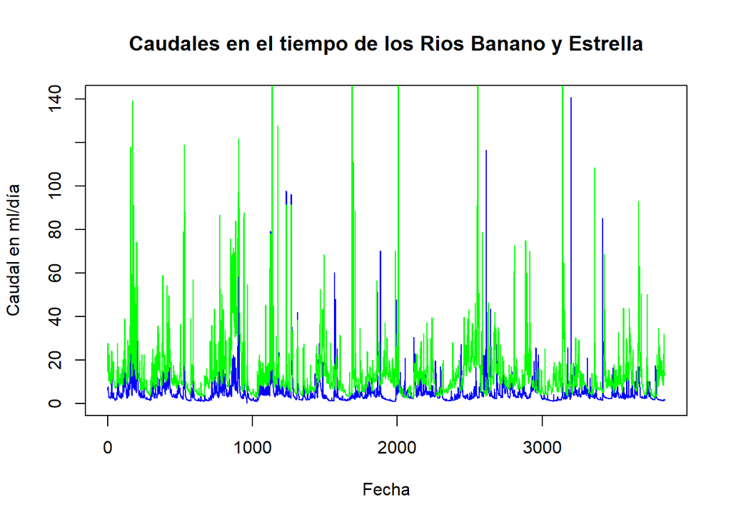

```r
inp <- read.csv("FDC.csv", na.strings="")
# Gráfico de caudales de los rios en estudio.
plot(inp[,2],
     main= "Caudales en el tiempo de los Rios Banano y Estrella",
     type = "l",
     col="blue",
     xlab = "Fecha",
     ylab = "Caudal en ml/día"
     )
lines(inp[,3],
      col= "green")
```

En el gráfico anterior se puede observar la comparativa entre ambos rios. Para un mayor orden visual durante el trabajo se utilizará el color verde para la representación del rio Banano y el color azul para representar el rio Estrella.

#### Comparativa estadistica

Resultado de la comparativa, los datos son medidos en ml.

```r
summary(inp[,2:3])
```

```
##  Pandora.mm..637km2. Banano.mm..90km2.
##  Min.   :  0.180     Min.   :  2.43
##  1st Qu.:  2.390     1st Qu.:  6.88
##  Median :  3.590     Median : 10.18
##  Mean   :  5.459     Mean   : 14.28
##  3rd Qu.:  5.900     3rd Qu.: 15.46
##  Max.   :140.650     Max.   :384.00
```

### Histogramas

Los histogramas en estadística son una representación gráfica de una variable en forma de barras.

##### Histograma del Rio Estrella

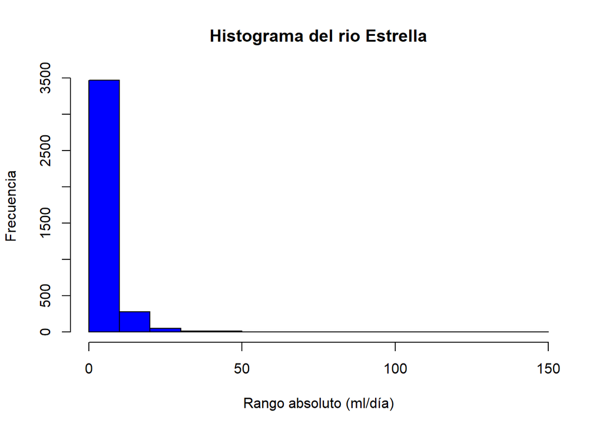

```r
hist(inp[,2],
     main = "Histograma del rio Estrella",
     xlab= "Rango absoluto (ml/día)",
     ylab = "Frecuencia",
     col= "blue"
     )
```

Se puede observar en este histograma como los datos no son parejos y se observa un caudal bajo en el rio Estrella.

##### Histograma del rio Banano

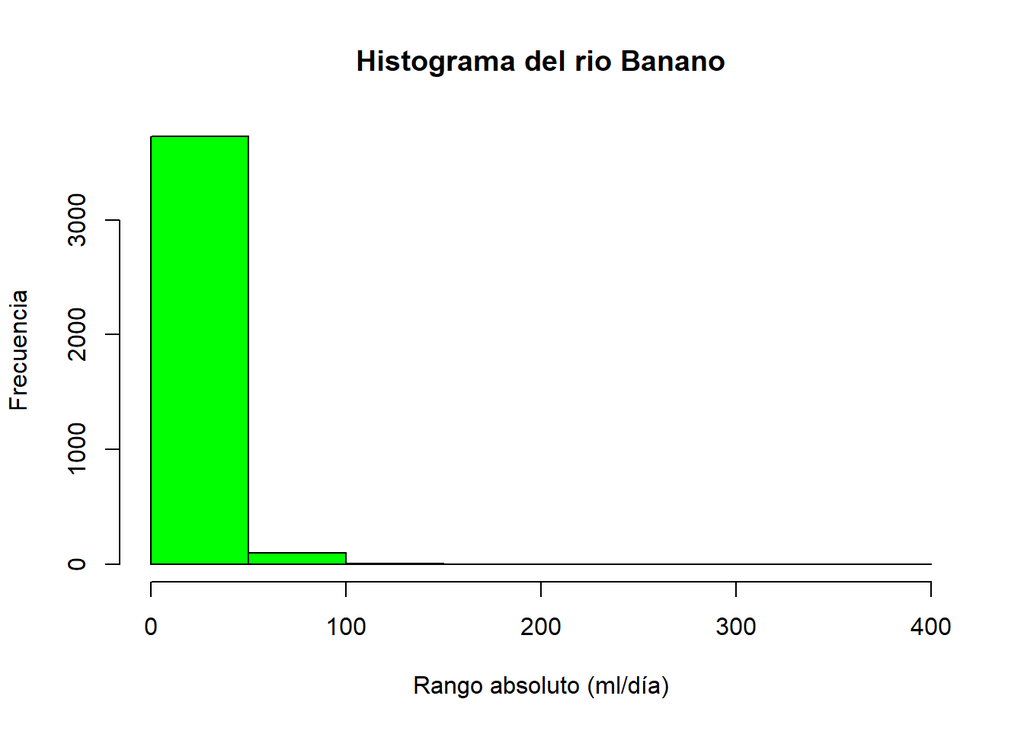

```r
hist(inp[,3],
     main = "Histograma del rio Banano",
     xlab = "Rango absoluto (ml/día)",
     ylab = "Frecuencia",
     col= "green"
     )
```

En este caso se puede observar un caudal mayor en el rio Banano en comparación al cuadal reportado para el rio Estrella.

Para una mejor visualización de los datos se adjudicaron nombres a las variables:

```r
names(inp) <- c("fecha", "Estrella", "Banano")
attach(inp)
```

```r
Tempdate <- strptime(inp[,1], format = "%d/%m/%Y")
```

```r
MAQ_Estrella <- tapply(Estrella, format(Tempdate, format = "%Y"), FUN=sum)
MAQ_Banano <- tapply(Banano, format(Tempdate, format = "%Y"), FUN=sum)
write.csv(rbind(MAQ_Banano, MAQ_Estrella), file = "MAQrbind.csv")
```

El código anterior fue utilizado para darle un formato a los datos del archivo y así poder crear los MAQ (Mean annual streamflow), además con el código "write.csv’ se creó un archivo para poder acceder fácilmente a los datos de cada MAQ con alguna herramienta, ejemplo: Excel.

### Gráfico de los acumulados anuales de ambos rios

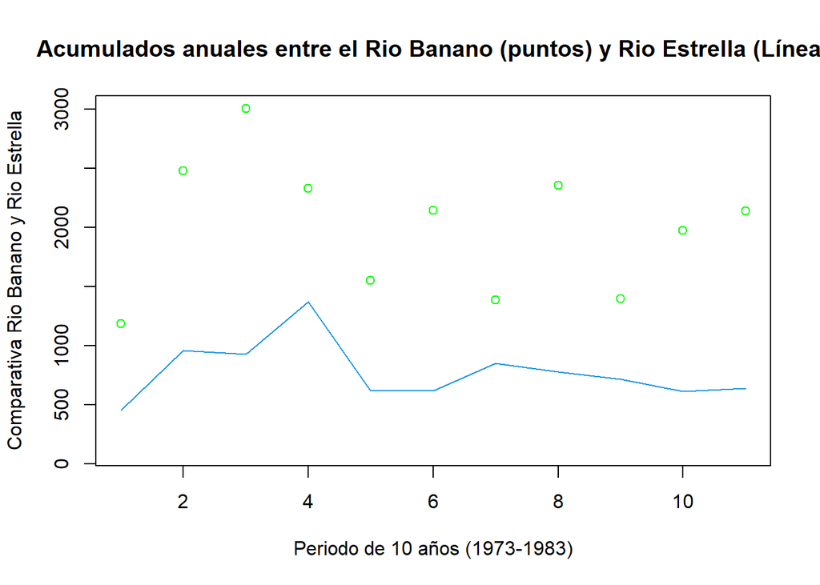

```r
plot(MAQ_Banano,
     main = "Acumulados anuales entre el Rio Banano (puntos) y Rio Estrella (Línea)",
     ylim=c(100,3000),
     ylab = "Comparativa Rio Banano y Rio Estrella",
     xlab = "Periodo de 10 años (1973-1983)",
     col= "green"
     )
lines(MAQ_Estrella,
      col=4,
      )
```

Con dicho gráfico se pueden identificar los “picos” en los caudales de cada río, en el año de 1975 para el Rio Banano y 1976 para el Rio Estrella, siendo estos años de fenómeno del niño en CR.

### Acumulados mensuales

```r
MMQ_Estrella <- tapply(Estrella, format(Tempdate, format = "%m"), FUN=sum)
MMQ_Banano <- tapply(Banano, format(Tempdate, format = "%m"), FUN=sum)
```

Este código es muy parecido al utilizado en los MAQ, simplemente se cambio su formato de año (%Y) a mes (%m), teniendo las precauciones de las minúsculas y además cambiando el nombre a MMQ (mean monthly streamflow).

### Gráfico acumulados mensuales

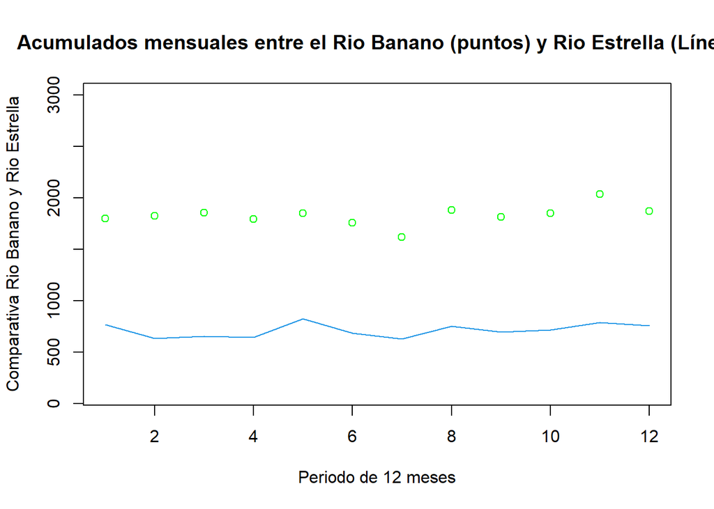

```r
plot(MMQ_Banano,
     main = "Acumulados mensuales entre el Rio Banano (puntos) y Rio Estrella (Línea)",
     ylim=c(100,3000),
     ylab = "Comparativa Rio Banano y Rio Estrella",
     xlab = "Periodo de 12 meses",
     col= "green"
     )
lines(MMQ_Estrella,
      col=4,
      )
```

En este gráfico se observan los “picos” nuevamente, pero en este caso se encuentran en el mes 11 (Noviembre) para el rio Banano y en le mes 5 (Mayo) para el rio Estrella.

### Correlación

##### Análisis de correlación con el método spearman:

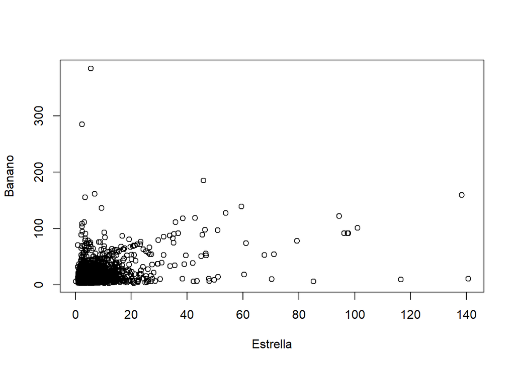

```r
corinp <- cor(inp[,2:3], method = "spearman")
# LLuvia de datos entre ambos rios
plot(Estrella, Banano)
```

Gráfico representativo de los datos del rio Estrella y Banano.

### Análisis explorativo de los datos en difetentes gráficos

```r
inp.lm <- lm(Estrella ~ Banano, data=inp)
summary(inp.lm)
```

```
##
## Call:
## lm(formula = Estrella ~ Banano, data = inp)
##
## Residuals:
##     Min      1Q  Median      3Q     Max
## -71.297  -2.267  -1.155   0.774 135.889
##
## Coefficients:
##             Estimate Std. Error t value Pr(>|t|)
## (Intercept)  2.70503    0.15174   17.83   <2e-16 ***
## Banano       0.19290    0.00707   27.28   <2e-16 ***
## ---
## Signif. codes:  0 '***' 0.001 '**' 0.01 '*' 0.05 '.' 0.1 ' ' 1
##
## Residual standard error: 7.025 on 3843 degrees of freedom
## Multiple R-squared:  0.1623, Adjusted R-squared:  0.162
## F-statistic: 744.4 on 1 and 3843 DF,  p-value: < 2.2e-16
```

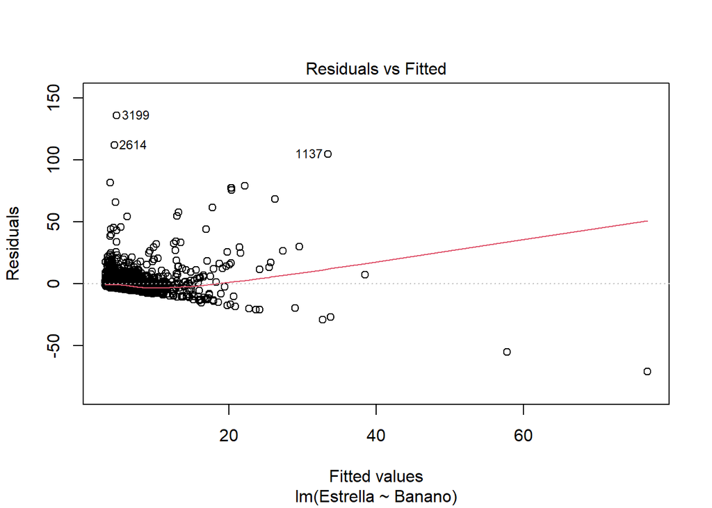

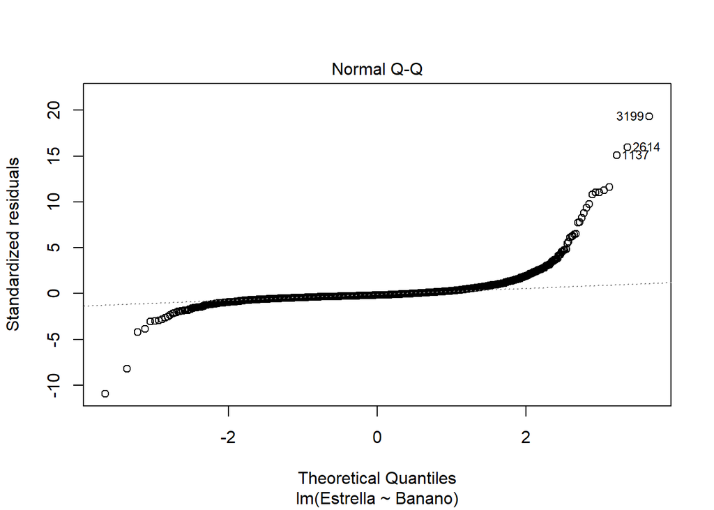

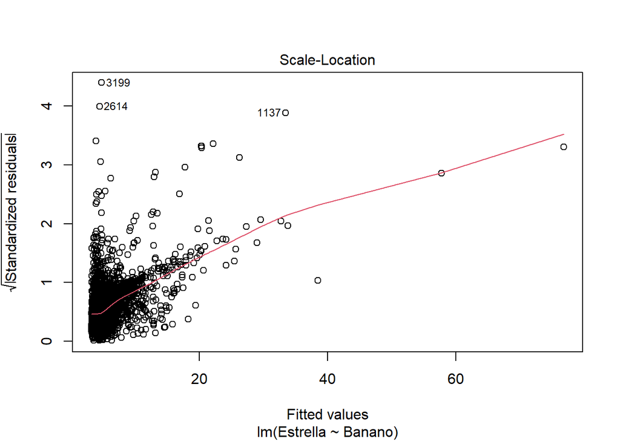

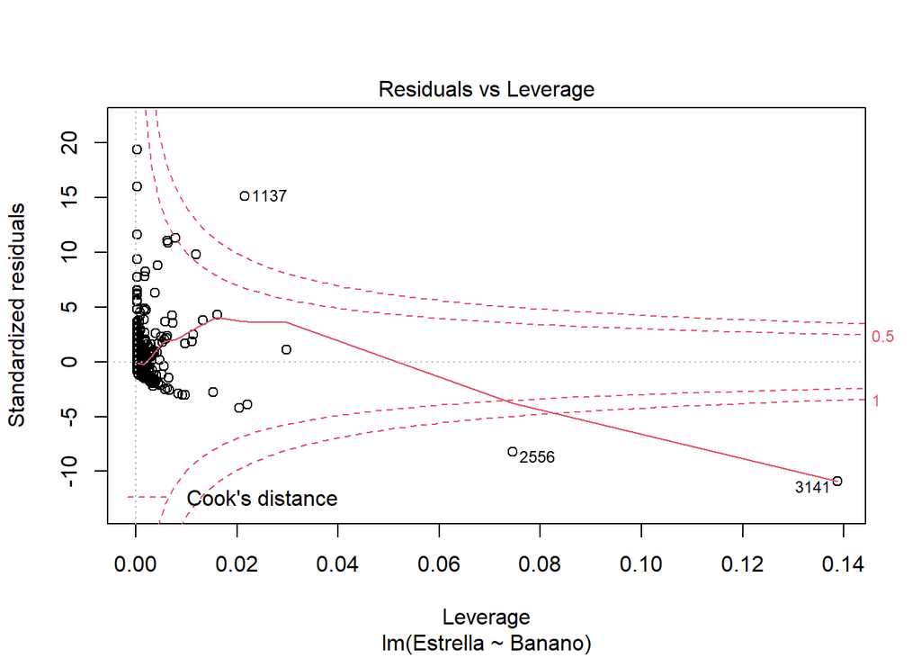

```r
plot(inp.lm)
```

Con este último plot se pueden observar los datos del summary en diferentes gráficos y realizar un analisis explorativo de cada uno.